# Parameters estimation for calibration

Simon Jean

2023-05-11

# I. Demand estimation

## A. Preliminary analysis : descriptive stats

### i. Average weight through time

First, look at the evolution of average weight per year :

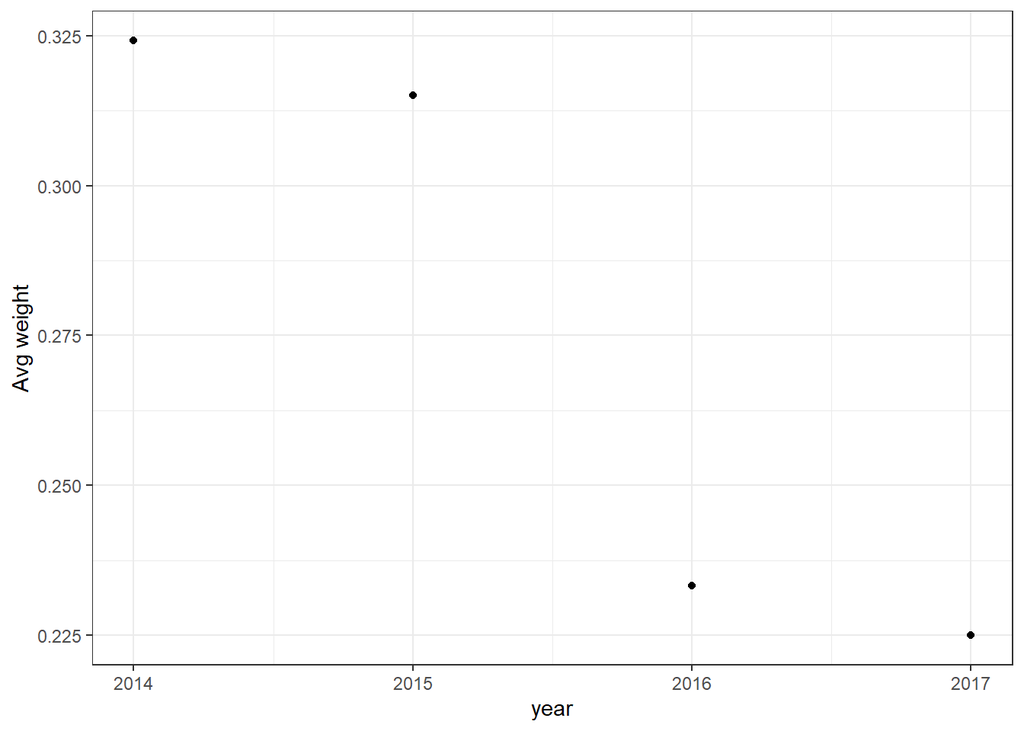

Observe a decrease of average weight. Second, look at the evolution of price per buche through time. To do so, I compute the product of `p` and `g` (price/gram * grams of buche).

### ii. Price of buche through time

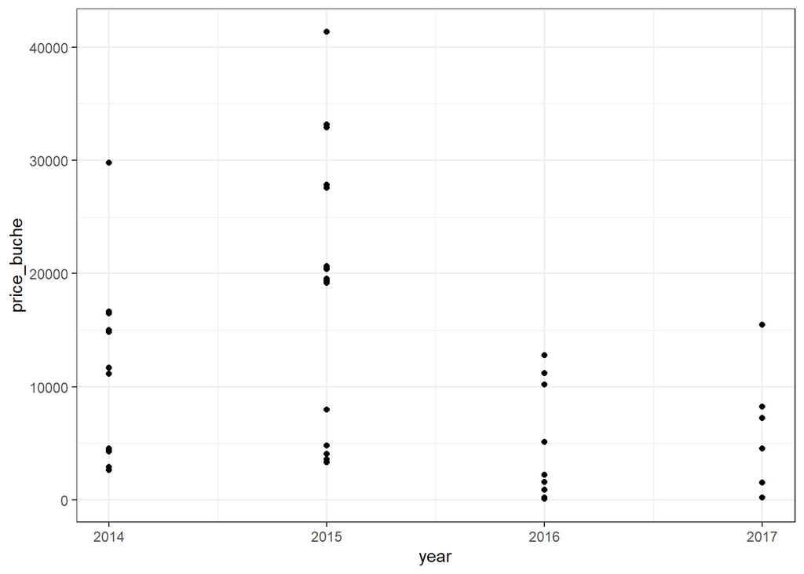

Conclusion : it seems like the market has evolved. It is hard to say whether (i) there was a crackdown a decrease in demand or (ii) supply increased.

### iii. Evolution of catch

That goes along with what follows : the catch has increased for years we have data for :

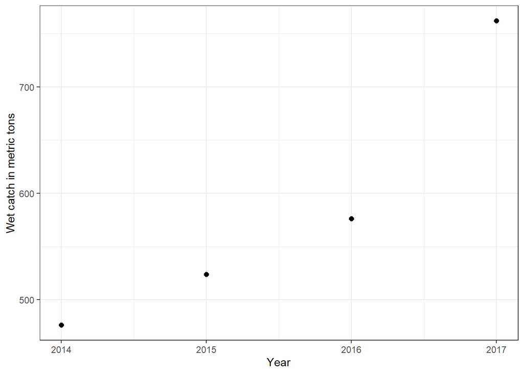

Assuming a constant demand, we can leverage that change in supply to estimate the demand function.

#### iv. Evolution of price per kilo for all size buche

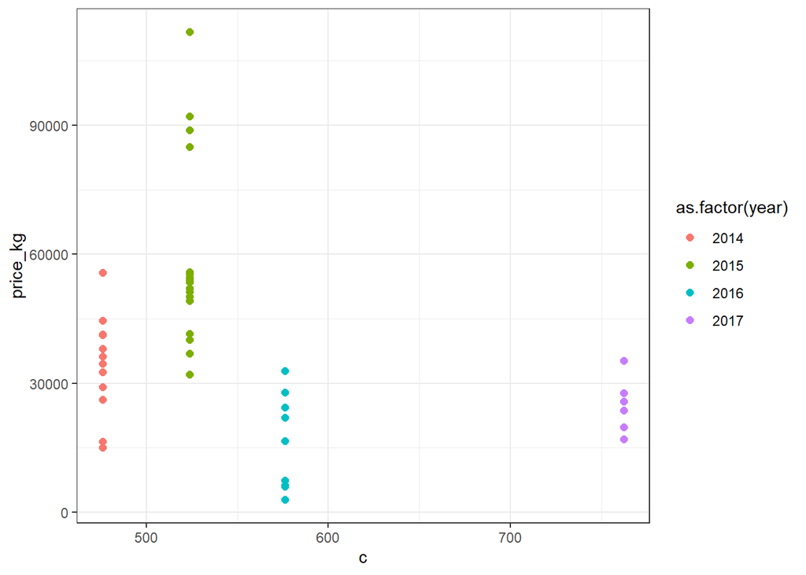

#### v. Evolution of price of largest size buche

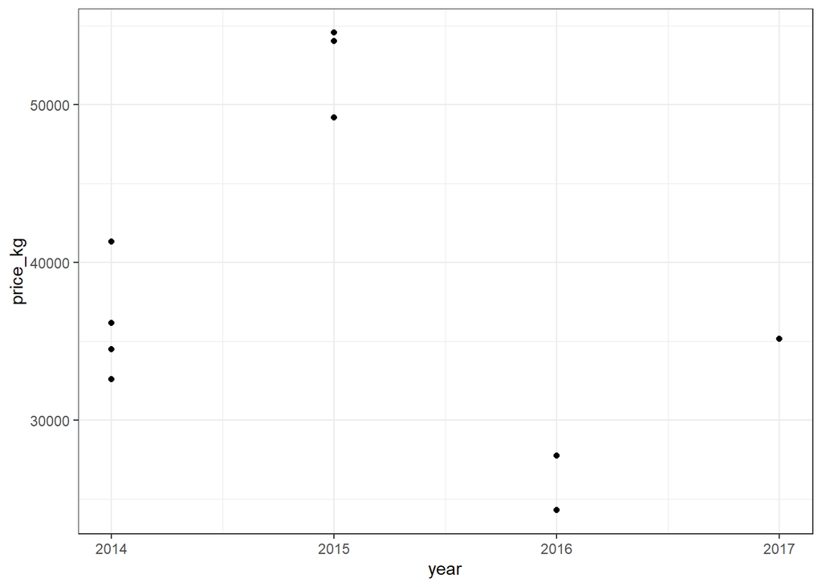

### B. Data reformating : dried totoaba, wet catch

First, recover individual totoaba poached from dried buche data. To do so:

1. `q` in `dat_p` is dried totoaba buche in tonnes : q*1000 is tonnes of dried totoaba buche
2. Given that we assume uniform distribution of totoaba size and that 1 totoaba = 500g of dried totoaba, then dried totoaba in kilos (converted to wet)/ 0.5 kilos -> Number of totoaba
3. Compare that to catch data :
- In `dat_p`, take `c` catch data in metric tonnes and convert to kilos (`c*1000`)
- Under the assumption of uniform distribution of size of caught totoaba, all weigh 25.7 kg (divide catch in kilos by average weight)

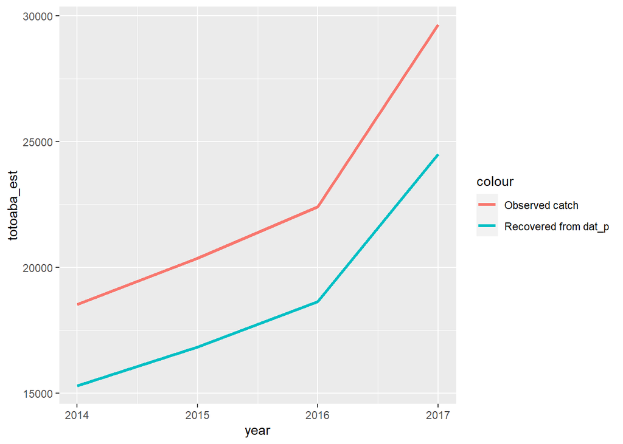

There is a big difference between estimates! Maybe it makes more sense to use price data per buche and observed catch.

### C. Graphical analysis of catch and biomass

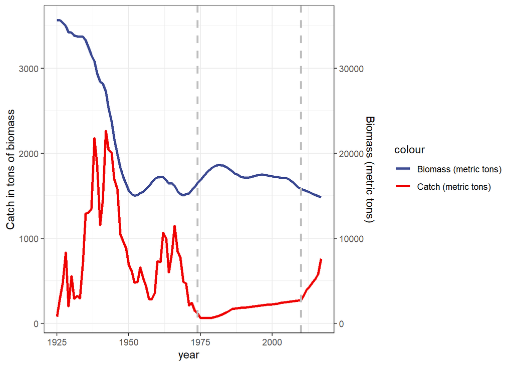

### D. Attempt 1 : use price per totoaba and variation in realized catch

In what follows :

- I use the variations in price per totoaba calculated as `price_per_totoaba = p*g` from `dat_p`.
- I use the variations in realized catch from `dat_bc`, converted to totoaba individuals assuming uniform weight distribution (`tototaba = c*1000/25.7`)

```
##
## Call:
## lm(formula = price_buche ~ totoaba, data = new_dat)
##
## Residuals:
##      Min       1Q   Median       3Q      Max
## -12461.3  -9525.8   -554.2   6058.8  27859.2
##
## Coefficients:
##               Estimate Std. Error t value Pr(>|t|)
## (Intercept) 31000.9433  9477.9770   3.271  0.00212 **
## totoaba        -0.8597     0.4347  -1.978  0.05441 .
## ---
## Signif. codes:  0 '***' 0.001 '**' 0.01 '*' 0.05 '.' 0.1 ' ' 1
##
## Residual standard error: 10060 on 43 degrees of freedom
## Multiple R-squared:  0.08337,    Adjusted R-squared:  0.06205
## F-statistic: 3.911 on 1 and 43 DF,  p-value: 0.05441
```

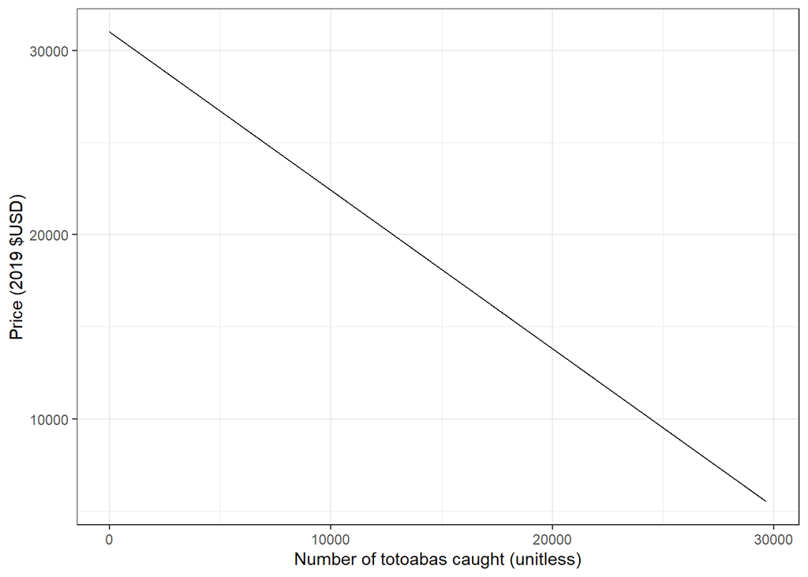

### D. Attempt 2 : Use price per totoaba and variation in estimated catch (converting dried buche tons to live totoaba)

Just to make sure we have results that are not too weird, I regress price on estimated catch.

[output not shown]

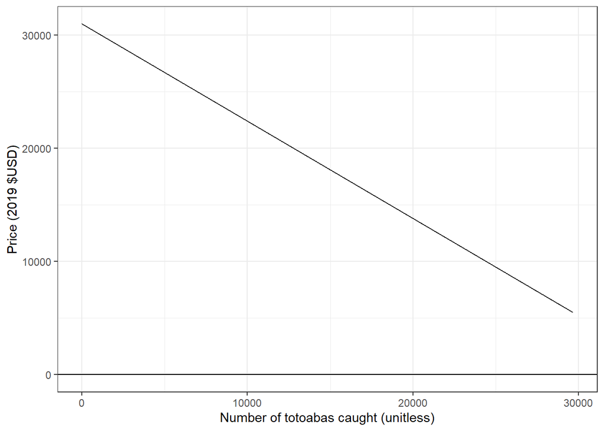

### E. Re-estimating demand in biomass units, and with the same pooled OLS method

We want an estimate that relates prices to quantities of biomass. Without any worry of conversion, I regress prices on caught biomass measured in *metric tons*. This model assumes no lag between poaching and selling.

$$\text{price buche}_{i} = \alpha + \beta \times catch_{i}$$

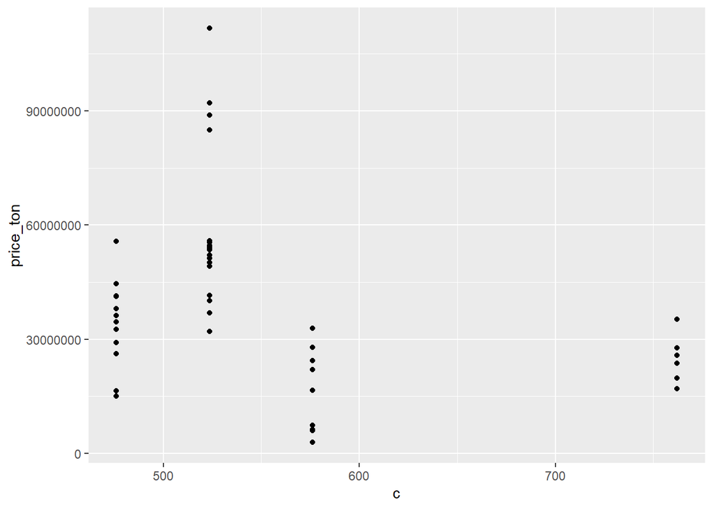

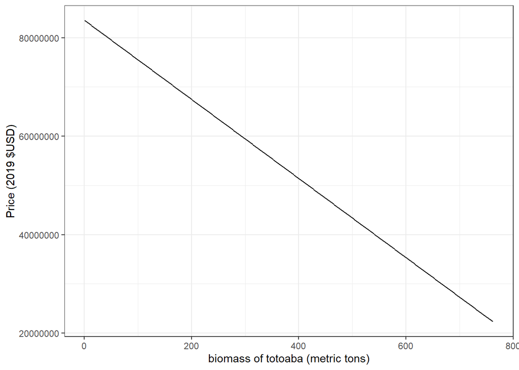

```
##
## Call:
## lm(formula = price_ton ~ c, data = new_dat)
##
## Residuals:
##       Min        1Q    Median        3Q       Max
## -34430339 -12685215  -2582822  10348585  70259926
##
## Coefficients:
##             Estimate Std. Error t value Pr(>|t|)
## (Intercept) 83568021   20908979   3.997 0.000248 ***
## c             -80377      37316  -2.154 0.036890 *
## ---
## Signif. codes:  0 '***' 0.001 '**' 0.01 '*' 0.05 '.' 0.1 ' ' 1
##
## Residual standard error: 22190000 on 43 degrees of freedom
## Multiple R-squared:  0.09739,    Adjusted R-squared:  0.0764
## F-statistic:  4.64 on 1 and 43 DF,  p-value: 0.03689
```

**Check what happens if we use the recovered values**

### F. Getting the units right

Previous demand estimation related price of buche to biomass of totoaba. However, this is not what we need to do. We need to have price of totoaba and biomass of totoaba. To do so, I’ll convert all price data based on the following conversion : $1 \text{kg of totoaba} = 0.019 \text{kg of buche}$. Therefore :

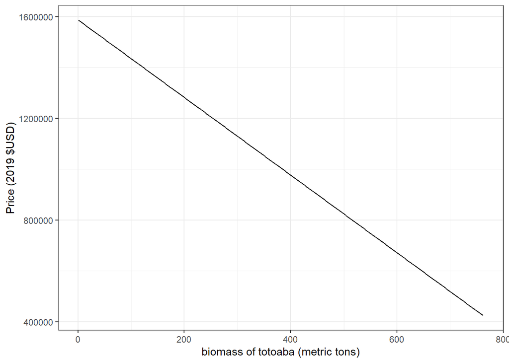

```
##
## Call:
## lm(formula = price_ton_toto ~ c, data = new_dat)
##
## Residuals:
##     Min      1Q  Median      3Q     Max
## -654176 -241019  -49074  196623 1334939
##
## Coefficients:
##             Estimate Std. Error t value Pr(>|t|)
## (Intercept)  1587792     397271   3.997 0.000248 ***
## c              -1527        709  -2.154 0.036890 *
## ---
## Signif. codes:  0 '***' 0.001 '**' 0.01 '*' 0.05 '.' 0.1 ' ' 1
##
## Residual standard error: 421600 on 43 degrees of freedom
## Multiple R-squared:  0.09739,    Adjusted R-squared:  0.0764
## F-statistic:  4.64 on 1 and 43 DF,  p-value: 0.03689
```

With this model, typically, observed catch in 2017 yields a price of 423.8828226 $ USD per kilo of totoaba. In this case, the value of a 25.7 kilos totoaba is 10893.78854 $, and therefore the kilo of buche sells at 21787.57708 $.

# II. Fish parameters

Julia has set up the growth and catchability parameters

# III. Estimating costs parameters

## A. Estimating cost parameter $W$

From Julia’s calculation, we have average cost. Now the procedure is to find the $W$ parameter that minimizes the difference between a straight cost and a quadratic cost.

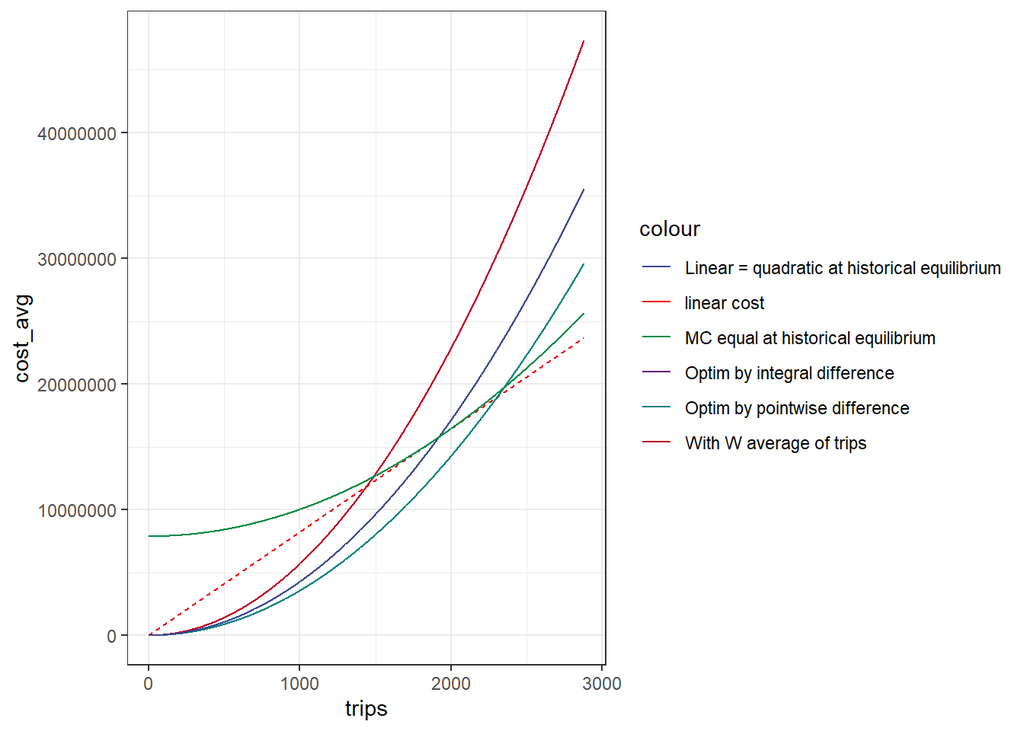

```
##                W_avg_trip  W_pointwise   W_integral W_exact_1920        MC_eq
##     1.500000     5.705097     3.565624     4.278749     4.278823     2.139411
```

Several points are worth noting : economic theory should favor the estimate of $W$ such that $MC(E^*)$ is equal for the linear and quadratic cost. This results in a sizeable difference, that can be fixed with a fixed cost parameter. In the end, this would yield the estimate of $W$ to be such that :
$$MC(E_{hist}) = 2WE_{hist} = \kappa \Rightarrow W =
\frac{\kappa}{2E_{hist}}$$
The question remains open as to if or how we control for the final difference in costs to assess profitability in equilibrium. I guess this goes to show that the discussion on the computation of profits is still not settled.

## B. Finding $c$

In this section, I just streamline the code for the parameter and show the variables we use for them. It is worth noting that $c$ so far is only estimated using data from the fishery cost data. It is likely that other costs come into play for transportation, that factor in the risks along the supply chain, and seizures.

# V. Simulating the model

### A. Parameters, units of measure

### B. Check calibration

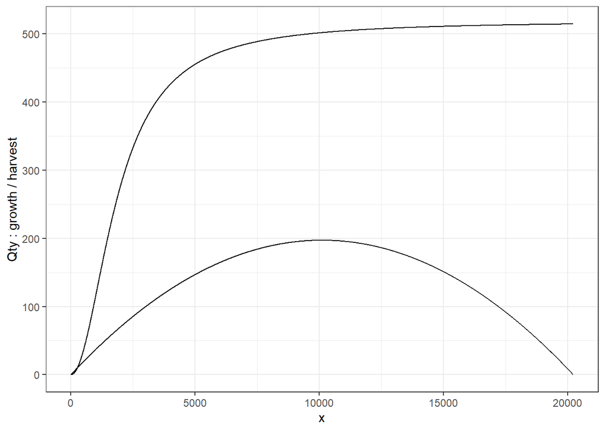

### C. Run prelim analysis : Cournot

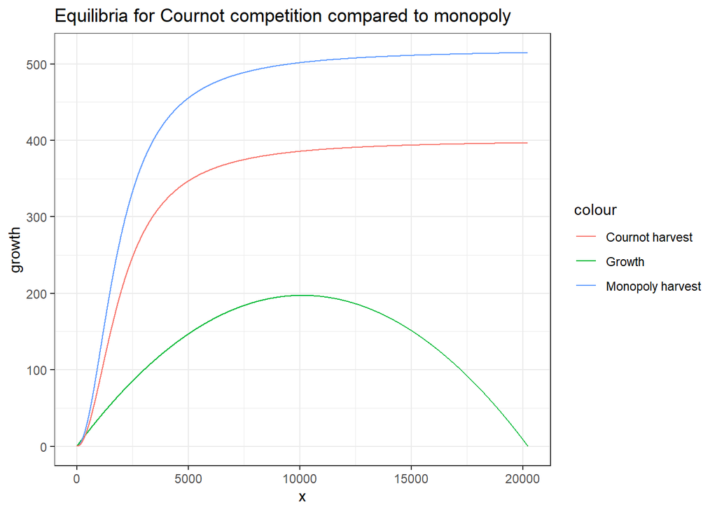

### D. Run prelim analysis : Bertrand

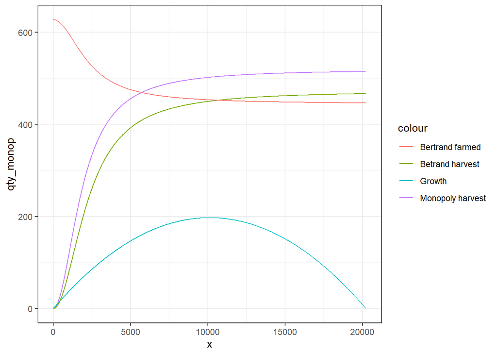

## E. Parse all

```
## [1] 265  NA  NA 384  NA  NA 427  NA  NA
```

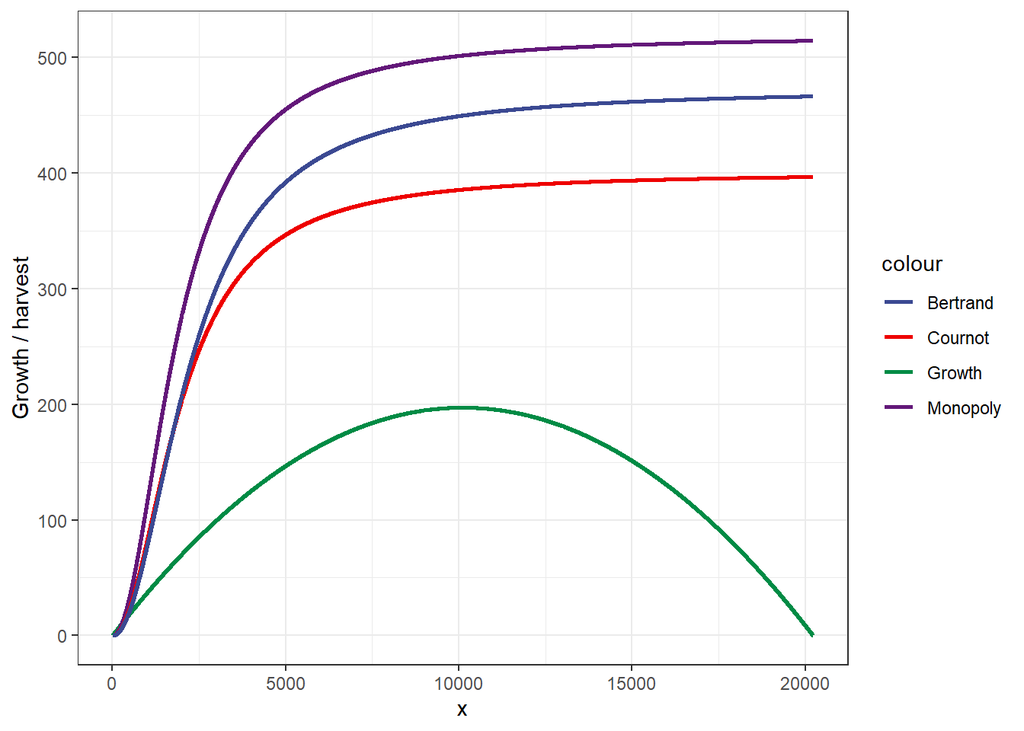

## F. Conclusion from preliminary results :

1. Competition only will not *radically* change the demise of totoaba
2. It may help to reach slightly larger steady state values, but will eventually lead to a drastic depletion of the stock
3. In order to change that dynamic, several interventions would be needed :
- For example, one could think about different $(\gamma, v)$ pairs
- Or consider the effect of being more competitive at the farming level
4. It is unclear what we can do to go beyond our results with this model.

# Analysis of new scenarios?

For example, can we think of ways that would curb the exploitation? For example, what about cracking down on demand, or technological research that makes production less costly? Or compare the impact of different cost measures for poaching, at the trader and poacher level?

# Table for parameters (values, concept and units)

Goal here is to leverage this table to do (i) sensitivity analysis and (ii) to investigate policy scenarios

Parameters used for calibration

| params | value | concept | units |
| --- | --- | --- | --- |
| alpha | 1587792.3966144 | Demand model : intercept | USD |
| beta | 1527.1598053 | Demand model : coefficient | USD/metric ton of biomass |
| r | 0.0390000 | intrinsic growth rate | unitless |
| k | 20226.0000000 | carrying capacity | metric tons of biomass |
| sigma | 0.0000142 | catchability | % of biomass/vessel trips |
| W_mid | 2.1394115 | Parameter cost such that MC are equal at historical value - middle | USD |
| W_low | 1.0396536 | Parameter cost such that MC are equal at historical value - low | USD |
| W_high | 3.4708125 | Parameter cost such that MC are equal at historical value - high | USD |
| avg_cost | 8215.3400000 | Average cost per vessel trip in data | USD |
| age | 4.0000000 | age of totoaba raised | years |
| gamma_prim | 0.6231808 | Substitution based on weight | unitless |
| gamma | 951.6967318 | Substitutability | unitless |
| v | 45172.0000000 | unit cost of farming | USD/ton of biomass |
| c | 2658.1972833 | unit costs associated with trading | USD/ton of biomass |

Several comments :

- $\alpha$ and $\beta$ : Demand may need further work. However, the estimates do not look too crazy.
  - However, there must be a conversion problem!!! One can relate the estimation of the price of buche to the catch of totoaba. However, when considering the revenue, the price applies to **the quantity of buche** not to the biomass of totoaba. Need to correct for that.
  - => Check for conversion : the conversion rate affects the outcome variable, so the coefficients change by the same proportion. Therefore, the cost effect increases slightly but it is not sufficient to bring back to a steady state.
- $r$ looks pretty solid
- $W$s are variable, but make little difference (I have tried with 2 to 10, no difference)
- $\sigma$ did not have much of an impact either
- $\gamma$ has to change and I’ll program a loop tomorrow to have all the realistic values : it needs to include the profit function of the farmers, to find which maximizes its profit. There might be some discounting at play here.
- $v$ can move but unless we pick a shorter rotation, it is more likely to go up if we include operational costs
  - We can have a $v_{net}$ parameter that influences the equilibrium. However, I’ve ran a couple of tests today, it seems that unless the subsidy is close to a 1,000,000 $/ton, it does not make a difference.
  - At some point, if profitability is what we aim at tackling, we need to have data on fixed costs and number of pens operating.
- $c$ can move a lot I think. Our estimate is based on fines, and bribes, and convictions on the fishery end. It’s a lot, but I’m sure there is an argument to increase it.

## Sensitivity analysis

The difference between the curves is very small. Several things could be changed from the way we work :

- $c$ seems too low. For now, $c$ includes only fishery related costs : other costs associated with transports, sanctions and seizures should be factored in. To do so, I’ll run a range of values for $c$ ranging from 100% to 500%
- $v$ seems low as well, as it only includes feed costs for aquaculture. I’ll run a range of values for $v$ ranging from 100% to 500%
- Our choice of $\gamma$ and $v$ are subject to change. $\gamma$ is difficult to take at face value : it is based on a weight ratio, and does not factor in a differential based on wild v. farmed totoaba. Although the weight may be the same, other quality characteristics such as fat content could play a role. In order to manage that, I’ll run all the potential values of $\gamma$ and $v$, with adjustment factors for $\gamma$ (from 70% to 100%)
- For $\alpha$, I’ll run specifications ranging from 80 to 120% of the value

```
## [1] "Distribution of monopoly steady states"
```

```
##    Min. 1st Qu.  Median    Mean 3rd Qu.    Max.
##     896     985    1096    1127    1238    1427
```

```
## [1] "Distribution of Cournot steady states"
```

```
##    Min. 1st Qu.  Median    Mean 3rd Qu.    Max.
##     896     985    1096    1127    1238    1428
```

```
## [1] "Distribution of Betrand steady states"
```

```
##    Min. 1st Qu.  Median    Mean 3rd Qu.    Max.
##     896     985    1096    1127    1238    1428
```